# 01_BIG_KNIT

# creating distance matrix of binding profile correlations

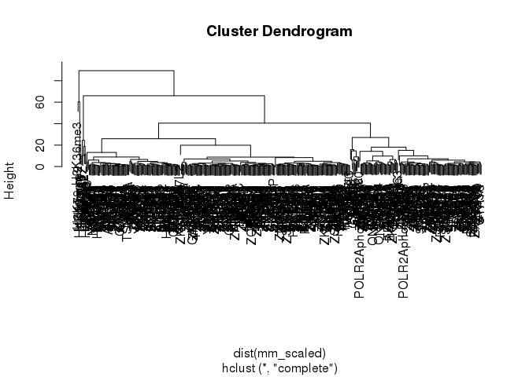

```r
metaplot_filtered_matrix <- metaplot_df %>%
  pivot_wider(names_from = x, values_from = dens) %>%
  column_to_rownames("dbp") %>%
  as.matrix()
mm_scaled <- t(scale(t(metaplot_filtered_matrix)))
metaplot_hclust <- hclust(dist(mm_scaled), method = "complete")

# plotting relationship between binding profiles
plot(metaplot_hclust)
```

```r
pdf("figures/tss_profile_dendrogram.pdf", height = 10, width = 27)
par(cex=0.3)
plot(metaplot_hclust)
dev.off()
```

# heat map of binding profile over +/- 1kb TSS window

```r
pdf("figures/tss_profile_heatmap.pdf", height = 35, width = 10)
Heatmap(mm_scaled, cluster_columns = FALSE,  border = TRUE,
        show_column_names = FALSE,
        use_raster = TRUE,
        column_gap = unit(0, "mm"),row_names_gp = gpar(fontsize = 7))
dev.off()
```

Result: (i) most binding profiles are over the TSS (ii) some binding profiles are more narrow directly over TSS (iii) histone mods tend to be depleted at TSS (probably NFR)

# looking more into the patterns of ChIP binding profiles relative to TSS

# breaking this down into several clusters and plotting each

```r
# Let's see how many DBPs have different patterns.
# manually checking at 6 we get a new group of 10 - after that not much changes
clusters <- cutree(metaplot_hclust, k=6)
table(clusters)
```

```
## clusters
##   1   2   3   4   5   6
## 281 130  10   5   1   3
```

```r
# plot cluter 1
dev.new()
pdf("figures/cluster_1_heatmap.pdf", height = 35, width = 10)

Heatmap(mm_scaled[clusters == 1,], cluster_columns = FALSE,  border = TRUE,
        show_column_names = FALSE,
        use_raster = TRUE,
        column_gap = unit(0, "mm"),row_names_gp = gpar(fontsize = 7))
graphics.off()

# cluster 2
dev.new()
pdf("figures/cluster_2_heatmap.pdf", height = 35, width = 10)

Heatmap(mm_scaled[clusters == 2,], cluster_columns = FALSE,  border = TRUE,
        show_column_names = FALSE,
        use_raster = TRUE,
        column_gap = unit(0, "mm"),row_names_gp = gpar(fontsize = 7))
graphics.off()

# cluster 3
dev.new()
pdf("figures/cluster_3_heatmap.pdf", height = 35, width = 10)
Heatmap(mm_scaled[clusters == 3,], cluster_columns = FALSE,  border = TRUE,
        show_column_names = FALSE,
        use_raster = TRUE,
        column_gap = unit(0, "mm"),row_names_gp = gpar(fontsize = 7))
graphics.off()
# very narrow binding over tss !

# cluster 4
dev.new()
pdf("figures/cluster_4_heatmap.pdf", height = 35, width = 10)
Heatmap(mm_scaled[clusters == 4,], cluster_columns = FALSE,  border = TRUE,
        show_column_names = FALSE,
        use_raster = TRUE,
        column_gap = unit(0, "mm"),row_names_gp = gpar(fontsize = 7))
graphics.off()

# looks like TSS depletion and histone mods

# cluster 5 only 1 DBP
names(clusters[5])
```

```
## [1] "AKAP8"
```

```r
# cluster 6
dev.new()
pdf("figures/cluster_6_heatmap.pdf", height = 35, width = 10)
Heatmap(mm_scaled[clusters == 6,], cluster_columns = FALSE, border = TRUE,
        show_column_names = FALSE,
        use_raster = TRUE,
        column_gap = unit(0, "mm"),row_names_gp = gpar(fontsize = 7))
graphics.off()

# TSS depletion and histone mods again.
```

Result: (i) Cluster 1 and 2 have broad TSS binding (cluster 2 is more narrow than cluster 1) (ii) Cluster 3 has very narrow binding right over tss (iii) cluster 4 and 6 have depletion over TSS (also mostly histone mods and EZH2) (iv) cluster 5 was not plotted as only has one DBP.

# establishing lncRNA and mRNA promoters (+/- 1kb)

```r
# creating promoters just in case:
lncrna_promoters <- lncrna_mrna_promoters[lncrna_mrna_promoters$gene_type == "lncRNA"]


mrna_promoters <- lncrna_mrna_promoters[lncrna_mrna_promoters$gene_type == "protein_coding"]
```

# metaplots for each DBP by lncRNA and mRNA promoters

```r
#setting up lncrna DF.
lncrna_metaplot_df <- data.frame(x = integer(), dens = numeric(), dbp = character())

# for loop to populate DF with overlap density in lncrna promoters
for(i in 1:length(filtered_consensus_list)) {
  #print(names(filtered_consensus_list)[[i]])
  tmp_df <- profile_tss(filtered_consensus_list[[i]], lncrna_mrna_promoters = lncrna_promoters)
  tmp_df$dbp <- names(filtered_consensus_list)[[i]]
  lncrna_metaplot_df <- bind_rows(lncrna_metaplot_df, tmp_df)

}

# saving
write_rds(lncrna_metaplot_df, "results/lncRNA_metaplot_df_final.rds")

# now for mRNAs
mrna_metaplot_df <- data.frame(x = integer(), dens = numeric(), dbp = character())

# for loop to populate mRNA_metaplot
for(i in 1:length(filtered_consensus_list)) {
 # print(names(filtered_consensus_list)[[i]])
  tmp_df <- profile_tss(filtered_consensus_list[[i]], lncrna_mrna_promoters = mrna_promoters)
  tmp_df$dbp <- names(filtered_consensus_list)[[i]]
  mrna_metaplot_df <- bind_rows(mrna_metaplot_df, tmp_df)

}

# saving mRNA metaplots
write_rds(mrna_metaplot_df, "results/mrna_metaplot_df_final.rds")


# now adding the information of gene type
mrna_metaplot_df$gene_type <- "mRNA"
lncrna_metaplot_df$gene_type <- "lncRNA"
combined_metaplot_profile <- bind_rows(mrna_metaplot_df, lncrna_metaplot_df)

# saving
write_rds(mrna_metaplot_df, "results/metaplot_df_final.rds")
```

# profile plots for lncRNA and mRNA promoters seperated for each DBP

[figure not shown]

```r
ggplot(combined_metaplot_profile,
       aes(x = x, y = dens, color = gene_type )) +
  geom_vline(xintercept = 0, lty = 2) +
  geom_line(size = 1.5) +
  facet_wrap(dbp ~ ., scales = "free_y") +
  ggtitle("Promoter Metaplot") +
  scale_x_continuous(breaks = c(-1000, 0, 1000),
                     labels = c("-1kb", "TSS", "+1kb"),
                     name = "") +
  ylab("Peak frequency") +
 scale_color_manual(values = c("#424242","#a8404c"))
```

```r
# saving
ggsave("figures/mega_meta_plot_lncRNA-mRNA.pdf", width = 49, height = 12)
```

Result: (i) Most DBPs show similar binding profiles between lncRNA/mRNA promoters (ii) a few interesting ones EZH2 is more bound over TSS of lncRNA promoters (iii) H2AFZ is the most depleted over TSS (iv) H3K4me2 is more enriched over lncRNA TSS (v) H3K4me1 is slightly more over lncRNA promoters (vi) ZNF460 has different pattern between mRNA and lncRNA promoters

# DBP Binding versus RNA expression output

Now we are going to explore how binding to a promoter relates to gene expression output. We will use RNAseq data from ENCODE in HEPG2. The data is RNA from differnet fractions – it was run throguh NF_CORE RNAseq pipeline v1.4.2

The data files are here:

```bash
# ENCODE report on experimental accessions used (fractionated and total RNA HEPG2)

# wget -O samples.txt "https://www.encodeproject.org/report.tsv?type=Experiment&status=released&assay_slims=Transcription&assay_slims=Transcription&replicates.library.biosample.donor.organism.scientific_name=Homo+sapiens&biosample_ontology.term_name=HepG2&biosample_ontology.classification=cell+line&assay_title=total+RNA-seq&files.read_length=50&limit=all&advancedQuery=date_released:[2009-01-01%20TO%202021-12-31]"

# This will give us a text file of the file names.

# wget -O files.txt "https://www.encodeproject.org/batch_download/?type=Experiment&status=released&assay_slims=Transcription&assay_slims=Transcription&replicates.library.biosample.donor.organism.scientific_name=Homo+sapiens&biosample_ontology.term_name=HepG2&biosample_ontology.classification=cell+line&assay_title=total+RNA-seq&files.read_length=50&limit=all&advancedQuery=date_released:[2009-01-01%20TO%202021-12-31]"
```

First we want to load in our final_samplesheet from 01_DESEQ_counts.Rmd # Reading in sample sheet

```r
# First let's read in the sample sheet to know what is what
samplesheet <- read_rds("../../../05_R_analyses/05_RNAseq/01_differential_expression/results/final_samplesheet.rds")
```

# reading in TPM values from Salmon for our analyses

```r
# reading in salmon tpm
salmon_tpm <- read.csv("../../../05_R_analyses/05_RNAseq/00_RNAseq_download_NF_core_pipeline/00_NF_CORE_RNAseq_Pipeline_run/results/salmon/salmon_merged_gene_tpm.csv")

# TPM table is in same order as samplesheet
tpm <- salmon_tpm %>%
  pivot_longer(cols = 2:ncol(.), names_to = "sample_id", values_to = "tpm") %>%
  merge(samplesheet) %>%
  group_by(gene_id, condition) %>%
  summarize(tpm = mean(tpm, na.rm = T)) %>%
  pivot_wider(names_from = condition, values_from = tpm, names_prefix = "tpm_")
```

# determining how many DBPs are bound at each promoter

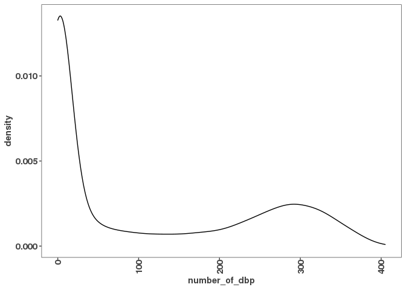

```r
# peak_occurrence_df is loaded in our environment and contains how many DBPs bind to each promoter (rows)
promoter_features_df <- merge(peak_occurrence_df, tpm)

# DBP density plot
ggplot(promoter_features_df, aes(x = number_of_dbp)) +
  geom_density()
```

```r
# saving
  ggsave("figures/DBP_binding_density_plot.pdf")
```

result: There appears to be a bimodal distribution of binding at promoters. those with less than 100dbps and those with more than 250

# Abundance of genes in each cellular fraction

```r
# First we need to the tpm DF into a matrix


tpm_matrix <- tpm %>%
  column_to_rownames("gene_id") %>%
  as.matrix()
tpm_scaled <- t(scale(t(tpm_matrix)))
tpm_scaled <- tpm_scaled[complete.cases(tpm_scaled),]


# plotting
new.env()
```

```
## <environment: 0x26f54a8a8>
```

```r
pdf("figures/heatmap_expression.pdf", height =49, width = 12)
pheatmap::pheatmap(tpm_scaled, show_rownames = FALSE)
graphics.off()
```

RESULT: (1) Most RNAs are abundant in the nucleus (2) Some RNAs expressed in total that are not in other fractions

# Plotting binding versus expression

Now let’s examine how binding effects expression. We have published previously that the more binding events at a promoter the more abundant the expression is. Let’s see if this holds for our current subset of DBPs

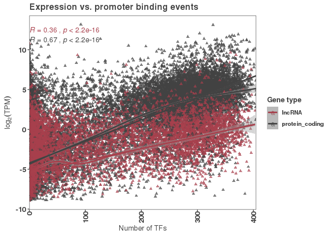

```r
# plotting binding vs total RNA expression
ggplot(promoter_features_df,
            aes(y = log2(tpm_homo_sapiens_hepg2 + 0.001), x = number_of_dbp, color = gene_type)) +
geom_point(data = promoter_features_df %>% filter(tpm_homo_sapiens_hepg2 > 0.001),
             shape = 17, alpha = 0.7) +
  geom_smooth(method = 'gam', formula = y ~ s(x, bs = "cs")) +
  stat_cor() +
  geom_smooth(method = "lm") +
  scale_x_continuous(expand = c(0,0)) +
  scale_color_manual(values = c("#a8404c", "#424242"), name = "Gene type") +
  ggtitle("Expression vs. promoter binding events") +
  xlab(expression('Number of TFs')) +
  ylab(expression(log[2](TPM)))
```

```r
ggsave("figures/binding_vs_expression_total_rna.pdf")
```

Result: (1) There is a linear trend with number of DBPS and expression levels (2) There is a population of genes that have numerous DBPs with low expression

# Binding versus nuclear expression

Let’s see if the binding versus expression holds in the nuclear fraction

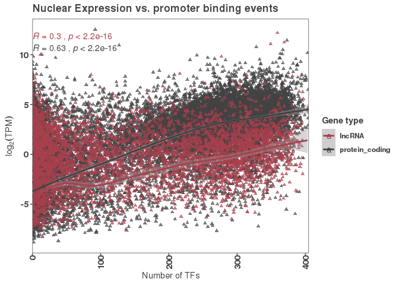

```r
# Now let's make a similar plot for nuclear RNA abundance versus #DBPs bound to their promoter
ggplot(promoter_features_df,
            aes(y = log2(tpm_homo_sapiens_nuclear_fraction + 0.001), x = number_of_dbp, color = gene_type)) +
  geom_point(data = promoter_features_df %>% filter(tpm_homo_sapiens_nuclear_fraction > 0.001),
             shape = 17, alpha = 0.7) +
  geom_smooth(method = 'gam', formula = y ~ s(x, bs = "cs")) +
  stat_cor() +
  scale_x_continuous(expand = c(0,0)) +
  scale_color_manual(values = c("#a8404c", "#424242"), name = "Gene type") +
  ggtitle("Nuclear Expression vs. promoter binding events") +
  xlab(expression('Number of TFs')) +
  ylab(expression(log[2](TPM)))
```

```r
  # saving figure
  ggsave("figures/nuclear_expression-vs-promoter_binding.pdf")
```

RESULT: (i) looks very similar to total RNA binding versus expression

# Binding versus cytoplasmic expression

Next we will determine the DBP binding versus cytoplasmic expression

```
# Same thing just seeing if there is a difference of cyto RNAs versus DBPs on promoter
ggplot(promoter_features_df,
            aes(y = log2(tpm_homo_sapiens_cytosolic_fraction + 0.001), x = number_of_dbp, color = gene_type)) +
  geom_point(data = promoter_features_df %>% filter(tpm_homo_sapiens_cytosolic_fraction > 0.001),
             shape = 17, alpha = 0.7) +
  geom_smooth(method = 'gam', formula = y ~ s(x, bs = "cs")) +
  stat_cor() +
  scale_x_continuous(expand = c(0,0)) +
  scale_color_manual(values = c("#a8404c", "#424242"), name = "Gene type") +
  ggtitle("Cytoplasmic Expression vs. promoter binding events") +
  xlab(expression('Number of TFs')) +
  ylab(expression(log[2](TPM)))
  # saving figure
  ggsave("figures/cytoplasmic_expression-vs-promoter_binding.pdf")
```